# What is the Trend Between Political Parties and Logical Beliefs? - Amogh Krishnan

```python
import numpy as np
from datascience import *

# These lines do some fancy plotting magic.
import matplotlib
%matplotlib inline
import matplotlib.pyplot as plt

# This is if you want your plots to have the FiveThirtyEight style
plt.style.use('fivethirtyeight')
```

```python
cah = Table.read_table('201709-CAH_PulseOfTheNation.csv')
```

## Introduction

In the recent political climate, there seems to have been a mix of politics and logical beliefs. Recent events have highlighted the partisan and political differences and divides on certain science and logic related issues. The COVID-19 outbreak, for example, highlighted the political divide in putting policies to control the COVID-19 virus. A Pew Research study had reported that Democrats were more likely than other parties to have a positive sentiment to vaccines and scientific research(Pasquini & Saks, 2022). Another example involved the overturning of Roe v. Wade which would allow abortion laws to be handled by the states, all of which are of different parties(Baker, 2022). And each party seems to hold different views on abortions. In this vein, government officials from each party seems to have differing opinions on logical structures in America. Therefore, I want to observe how the party an average American citizen chose relates to their logical beliefs. What is the trend or relationship between an average citizen's party and their logical beliefs? For this study, I will be using and analyzing a sample from the Cards Against Humanity, Pulse of the Nation dataset. I will be evaluating the Political Affiliation, Automation, Vaccines, Books, Ghosts, Climate Change, Scientists, Scientific Research, Federal Funding of Scientific Research, and Age variables. The Automation variables answers whether a participant believes that automation is likely or unlikely to replace humans in their jobs. Vaccines discusses whether a person agrees or disagrees about the benefits and safety of vaccines. Books discusses how many books the person read. Ghosts answers whether a person believes in ghosts or not. Climate Change discusses whether a participant believes climate change is real or not. Scientists evaluates whether a person believes that scientists are doing good for the public. Scientific Research shows how much the participant estimates the amount spent on research to be, in percentage. Federal Funding in Scientific Research evaluates whether a person thinks the funding for scientific research is About Right, Too High, or Too Low. I am using these variables as they describe a person's logic and belief on modern science or superstition. I am also going to compare them with the Political Affiliation table to see whether there is a pattern. The Political Affiliations in this study are Democrat, Republican, Independent, and DK/REF(Don't Know/Refused to Answer). DK/REF can be assumed to be undecided or they didn't answer what their party was. Age is also used since their ages could affect their life experiences which could affect their logical beliefs

## Data Description

Overall, there are 310 people in this table. Of those people, 120 are Independent, 72 are Republican, 87 are Democrat, and 31 are DK/REF. The highest number and percentage of participants who said that it was likely that automation will replace humans in the workforce was for the Democrat group(23 participants, 38.33%). The lowest count was for DK/REF(7 people, 11.67%). The highest percentage of people who said that such an event is unlikely came from the Independent party(39.92%). The Independent and Democratic parties had higher percentages of saying "No" to ghosts being real but also saying "Yes." However, there were more counts for saying "No" for all parties than for answering "Yes." Therefore, it's more likely that regardless of political party, the belief of ghosts or paranormal phenomena was less likely. Democrats had very high counts for "Strongly Agree"(42) on their opinion that scientists were good for the nation. Democrats and DK/REF had the lowest count for "Strongly Disagree." Repbulicans were more likely to answer moderately, answering "Somewhat Agree" or "Somewhat Disagree." Independents were also highly likely in count to agree that scientists are beneficial. Democrats and Independents had the highest count and percentage of strongly agreeing or somewhat agreeing that vaccines are safe and beneficial. Republicans had the most counts and percentages for somewhat disagreeing. Although "Strongly Disagree" generally had a low count, Independents had the highest number. For climate change, the counts and percentages for DK/REF were equally split by 25%. Democrats were significantly more likely to answer that climate change is real and caused by people as most of them(69) answered this while only 5 democrats said it is "Not Real" and only 9 said "Real and Not Caused by People". In comparison, there were a higher amount of Independents and Republicans who answered that climate change was not real or real and not caused by other people. And there were significantly less Republicans who agreed that climate change was real and caused by people. A high number of democrats thought the funding for research was too low. Independents also had a high number for this answer but a majority of them also had a high number thinking it was about right. Republicans found the funding to be at the right amount.

```python
CAHNation = Table.read_table('201709-CAH_PulseOfTheNation.csv')
```

```python
politic = CAHNation.select("Political Affiliation", "Age", "Automation","Vaccines","Books", "Ghosts", "Scientists",
                           "Climate Change", "Scientific Research",
                           "Federal Funding of Scientific Research")
#This table gathers the political affiliations and logical beliefs
```

```python
def percent(array_column):
    return (array_column/sum(array_column))*100
#This function calculates percentages for the counts
```

```python
politicPivA = politic.pivot("Automation", "Political Affiliation")
politicPivA
```

| Political Affiliation | DK/REF | Likely | Unlikely |
| --- | --- | --- | --- |
| DK/REF | 2 | 7 | 22 |
| Democrat | 3 | 23 | 61 |
| Independent | 5 | 20 | 95 |
| Republican | 2 | 10 | 60 |

```python
label = politicPivA.labels

politicAprop = Table().with_columns(label[0], politicPivA.column(0),label[1], percent(politicPivA.column(1)),
                                     label[2], percent(politicPivA.column(2)),
                                     label[3], percent(politicPivA.column(3)),
                                     )
politicAprop.show()
```

| Political Affiliation | DK/REF | Likely | Unlikely |
| --- | --- | --- | --- |
| DK/REF | 16.6667 | 11.6667 | 9.2437 |
| Democrat | 25 | 38.3333 | 25.6303 |
| Independent | 41.6667 | 33.3333 | 39.916 |
| Republican | 16.6667 | 16.6667 | 25.2101 |

```python
politicPivG = politic.pivot("Ghosts", "Political Affiliation")
politicPivG
```

| Political Affiliation | DK/REF | No | Yes |
| --- | --- | --- | --- |
| DK/REF | 1 | 20 | 10 |
| Democrat | 0 | 56 | 31 |
| Independent | 6 | 66 | 48 |
| Republican | 1 | 45 | 26 |

```python
labelGhost = politicPivG.labels

politicGprop = Table().with_columns(labelGhost[0], politicPivG.column(0),labelGhost[1], percent(politicPivG.column(1)),
                                     labelGhost[2], percent(politicPivG.column(2)),
                                     labelGhost[3], percent(politicPivG.column(3)),
                                     )
politicGprop.show()
```

| Political Affiliation | DK/REF | No | Yes |
| --- | --- | --- | --- |
| DK/REF | 12.5 | 10.6952 | 8.69565 |
| Democrat | 0 | 29.9465 | 26.9565 |
| Independent | 75 | 35.2941 | 41.7391 |
| Republican | 12.5 | 24.0642 | 22.6087 |

```python
politicPivS = politic.pivot("Scientists", "Political Affiliation")
politicPivS
```

| Political Affiliation | DK/REF | Neither Agree nor Disagree | Somewhat Agree | Somewhat Disagree | Strongly Agree | Strongly Disagree |
| --- | --- | --- | --- | --- | --- | --- |
| DK/REF | 3 | 1 | 7 | 2 | 13 | 5 |
| Democrat | 2 | 1 | 25 | 10 | 42 | 7 |
| Independent | 2 | 0 | 47 | 18 | 43 | 10 |
| Republican | 1 | 2 | 34 | 17 | 9 | 9 |

```python
labelScience = politicPivS.labels

politicSprop = Table().with_columns
(labelScience[0], politicPivS.column(0),
 labelScience[1], percent(politicPivS.column(1)),
labelScience[2], percent(politicPivS.column(2)),
labelScience[3], percent(politicPivS.column(3)),labelScience[4], percent(politicPivS.column(4)),
labelScience[5], percent(politicPivS.column(5)),labelScience[6], percent(politicPivS.column(6)),
                                     )
politicSprop.show()
```

[output not shown]

```python
politicPivV = politic.pivot("Vaccines", "Political Affiliation")
politicPivV
```

| Political Affiliation | DK/REF | Neither Agree nor Disagree | Somewhat Agree | Somewhat Disagree | Strongly Agree | Strongly Disagree |
| --- | --- | --- | --- | --- | --- | --- |
| DK/REF | 2 | 0 | 8 | 0 | 18 | 3 |
| Democrat | 1 | 0 | 16 | 7 | 59 | 4 |
| Independent | 3 | 1 | 24 | 3 | 82 | 7 |
| Republican | 0 | 0 | 15 | 8 | 47 | 2 |

```python
labelVaccines = politicPivV.labels

politicVprop = Table().with_columns(labelVaccines[0], politicPivV.column(0),
                                     labelVaccines[1], percent(politicPivV.column(1)),
                                     labelVaccines[2], percent(politicPivV.column(2)),
                                     labelVaccines[3], percent(politicPivV.column(3)),
                                     labelVaccines[4], percent(politicPivV.column(4)),
                                     labelVaccines[5], percent(politicPivV.column(5)),
                                     labelVaccines[6], percent(politicPivV.column(6)),
                                     )
politicVprop.show()
```

| Political Affiliation | DK/REF | Neither Agree nor Disagree | Somewhat Agree | Somewhat Disagree | Strongly Agree | Strongly Disagree |
| --- | --- | --- | --- | --- | --- | --- |
| DK/REF | 33.3333 | 0 | 12.6984 | 0 | 8.73786 | 18.75 |
| Democrat | 16.6667 | 0 | 25.3968 | 38.8889 | 28.6408 | 25 |
| Independent | 50 | 100 | 38.0952 | 16.6667 | 39.8058 | 43.75 |
| Republican | 0 | 0 | 23.8095 | 44.4444 | 22.8155 | 12.5 |

```python
politicPivC = politic.pivot("Climate Change", "Political Affiliation")
politicPivC
```

| Political Affiliation | DK/REF | Not Real At All | Real and Caused by People | Real but not Caused by People |
| --- | --- | --- | --- | --- |
| DK/REF | 4 | 5 | 16 | 6 |
| Democrat | 4 | 5 | 69 | 9 |
| Independent | 4 | 24 | 71 | 21 |
| Republican | 4 | 21 | 26 | 21 |

```python
labelClimate = politicPivC.labels

politicCprop = Table().with_columns
(labelClimate[0], politicPivC.column(0),
labelClimate[1], percent(politicPivC.column(1)),
labelClimate[2], percent(politicPivC.column(2)),
 labelClimate[3], percent(politicPivC.column(3)),
labelClimate[4], percent(politicPivC.column(4)),
                                     )
politicCprop.show()
```

[output not shown]

```python
politicPivF = politic.pivot("Federal Funding of Scientific Research", "Political Affiliation")
politicPivF
```

| Political Affiliation | About Right | DK/REF | Too High | Too Low |
| --- | --- | --- | --- | --- |
| DK/REF | 7 | 0 | 4 | 20 |
| Democrat | 20 | 5 | 11 | 51 |
| Independent | 45 | 9 | 9 | 57 |
| Republican | 43 | 3 | 11 | 15 |

```python
labelFF = politicPivF.labels

politicFprop = Table().with_columns
(labelFF[0], politicPivF.column(0),
labelFF[1], percent(politicPivF.column(1)),
labelFF[2], percent(politicPivF.column(2)),
labelFF[3], percent(politicPivF.column(3)),
labelFF[4], percent(politicPivF.column(4)),
                                     )
politicFprop.show()
```

[output not shown]

```python
politicBF = politic.select("Political Affiliation", "Age", "Books", "Scientific Research")
```

```python
politicBFMean = politicBF.group("Political Affiliation", collect = np.mean)
politicBFMean
```

| Political Affiliation | Age mean | Books mean | Scientific Research mean |
| --- | --- | --- | --- |
| DK/REF | 47.1613 | 64.2258 | 25.2903 |
| Democrat | 53.8046 | 14.4828 | 20.3966 |
| Independent | 50.9917 | 23.7333 | 17.2958 |
| Republican | 55.2222 | 17.0139 | 18.3611 |

Republicans had the oldest age mean, 55.22 years, followed by Democrats, 53.80 years, Independents, 51 years, and DK/REF, 47.16 years. The highest mean number of books read comes from the DK/REF people and the Independent parties. The more traditional parties, in comparison, had lower counts. The DK/REF people also estimated the amount spent on scientific research higher than the other parties had.

```python
politicBFMedian = politicBF.group("Political Affiliation", collect=np.median)
politicBFMedian
```

| Political Affiliation | Age median | Books median | Scientific Research median |
| --- | --- | --- | --- |
| DK/REF | 50 | 12 | 10 |
| Democrat | 54 | 6 | 10 |
| Independent | 51.5 | 5 | 10 |
| Republican | 55.5 | 5.5 | 10 |

## Visualizations

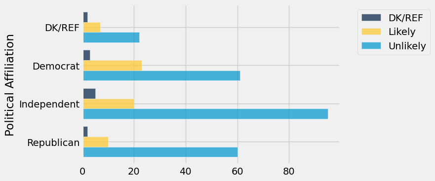

```python
Automationbar = politicPivA.barh("Political Affiliation")
Automationbar
```

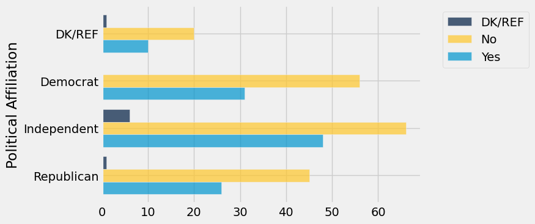

```python
Ghostbar = politicPivG.barh("Political Affiliation")
Ghostbar
```

This bar charts shows the distribution of opinions on whether ghosts are real among political affiliation. However, the Independents and Democrats had a higher count for "No." Republicans and DK/REFs were less likely to say "No" than the other parties were. However, Indepedents had the highest number of saying "Yes" to ghosts being real.

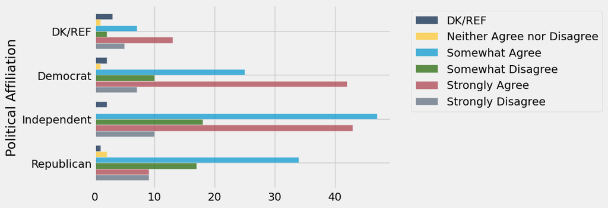

```python
Scientistbar = politicPivS.barh("Political Affiliation")
Scientistbar
```

This bar chart describes the distribution of counts for answers of whether scientists are honest and good for the public based on political affiliation. DK/REF had low counts for all answers. Democrats were a lot more likely to say "Strongly Agree" than they were for other answers. Independents were also likely to agree, either strongly or somewhat. Republicans had more moderate positions, having high counts for either somewhat agreeing or disagreeing.

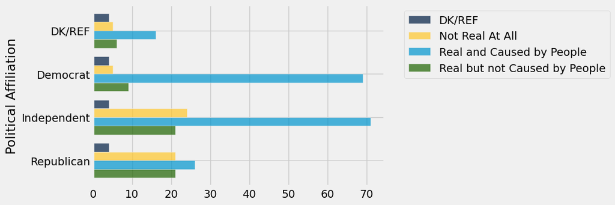

```python
ClimateChangebar = politicPivC.barh("Political Affiliation")
ClimateChangebar
```

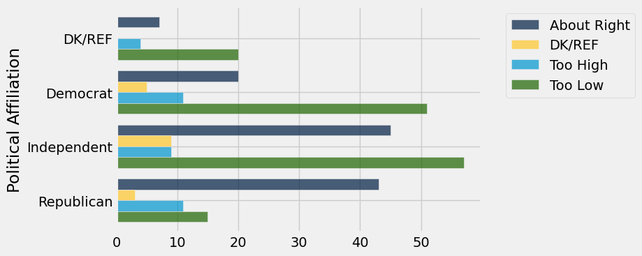

```python
FundingResearchbar = politicPivF.barh("Political Affiliation")
FundingResearchbar
```

This bar chart shows the distribtution of opinions for the federal funding of scientific research for all political affiliations. Democrats were way more likely to consider the amount of funding too low. Independents either had a high amount saying the funding was just right or too low. Republicans were strongly likely to say the funding was about right.

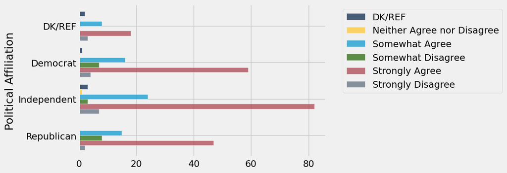

```python
Vaccinebar = politicPivV.barh("Political Affiliation")
Vaccinebar
```

This bar chart describes the distribution of opinions of the safety of vaccines based on political affiliation. Democrats were very likely to strongly agree that vaccines are safe, having a strong and positive position on this. The same trend occured with Independents, even though they were a little more likely to say "Somewhat Agree." Republicans were less likely to agree, either strongly or somewhat, even though a majority of them agreed. There were also a higher number of people in the Republican party somewhat disagreeing.

```python
politicDem = politic.where("Political Affiliation", are.equal_to("Democrat"))
```

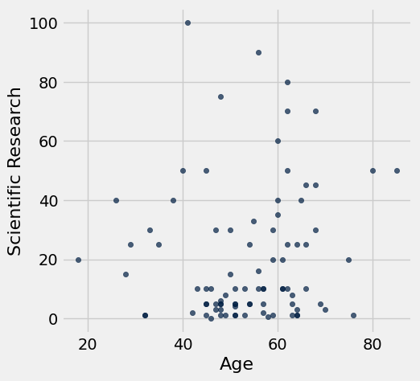

```python
politicDem.scatter("Age", "Scientific Research")
```

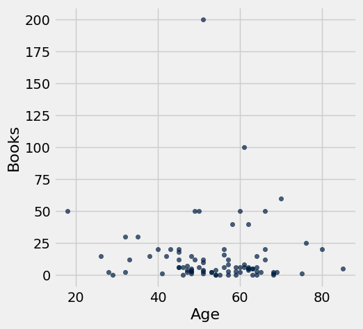

```python
politicDem.scatter("Age", "Books")
```

There is no association between Age and Scientific Research or Age and Books for the Democratic party.

```python
politicDBooks = politicDem.select("Books")
```

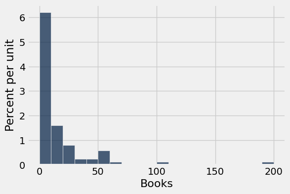

```python
politicDhis = politicDBooks.hist(bins=20)
politicDhis
```

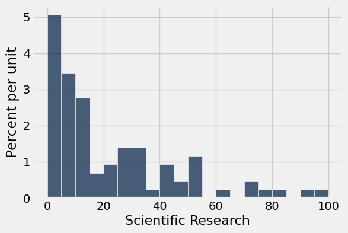

```python
politicDS = politicDem.select("Scientific Research")
politicShis = politicDS.hist(bins=20)
politicShis
```

```python
politicRep = politic.where("Political Affiliation", are.equal_to("Republican"))
```

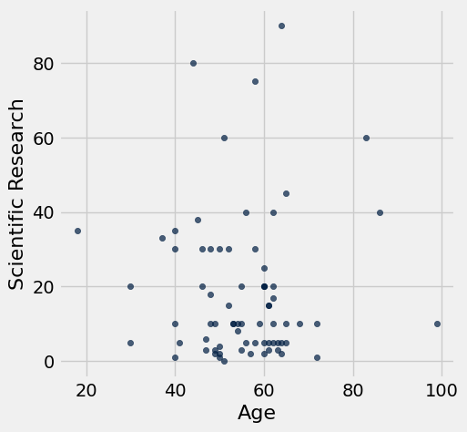

```python
politicRep.scatter("Age", "Scientific Research")
```

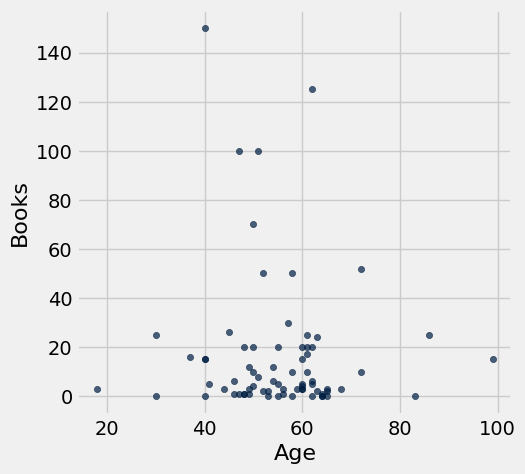

```python
politicRep.scatter("Age", "Books")
```

There is no association between Age and Scientific Research or Age and Books for the Republican party.

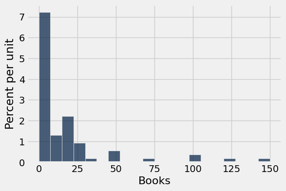

```python
politicRBooks = politicRep.select("Books")
politicRhis = politicRBooks.hist(bins=20)
politicRhis
```

[figure not shown]

```python
politicRScience = politicRep.select("Scientific Research")
politicRS = politicRGhosts.hist(bins=20)
politicRS
```

```python
politicInd = politic.where("Political Affiliation", are.equal_to("Independent"))
```

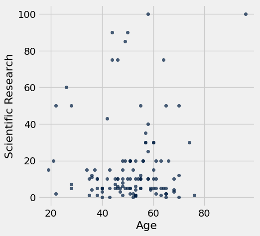

```python
politicInd.scatter("Age", "Scientific Research")
```

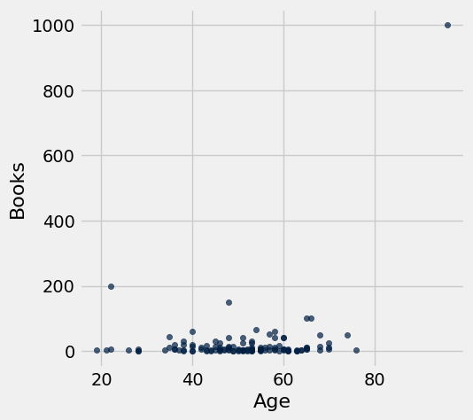

```python
politicInd.scatter("Age", "Books")
```

There is no association between Age and Scientific Research for the Independent party. An outlier might be creating a small positive association for age and books read.

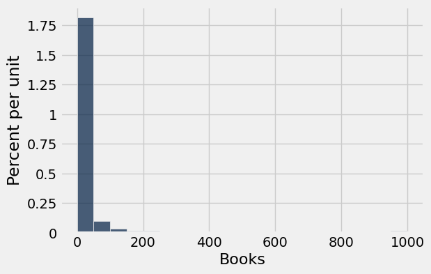

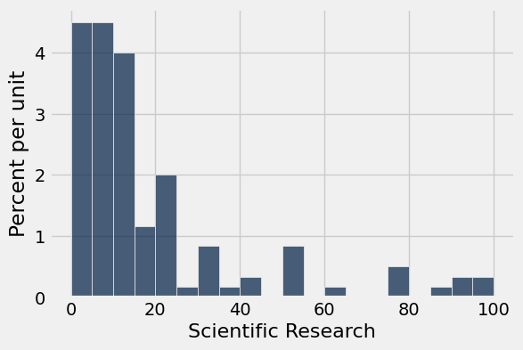

```python
politicIBooks = politicInd.select("Books")
politicIBhis = politicIBooks.hist(bins=20)
politicIBhis
politicIS = politicInd.select("Scientific Research")
politicIShis = politicIS.hist(bins=20)
politicIShis
```

```python
politicDKREF = politic.where("Political Affiliation", are.equal_to("DK/REF"))
```

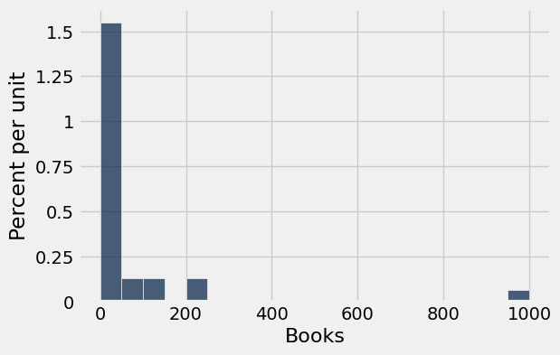

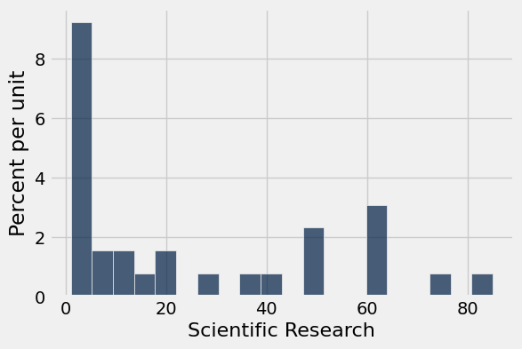

```python
politicDKBooks = politicDKREF.select("Books")
politicDKBhis = politicDKBooks.hist(bins=20)
politicDKBhis
politicDKS = politicDKREF.select("Scientific Research")
politicDKShis = politicDKS.hist(bins=20)
politicDKShis
```

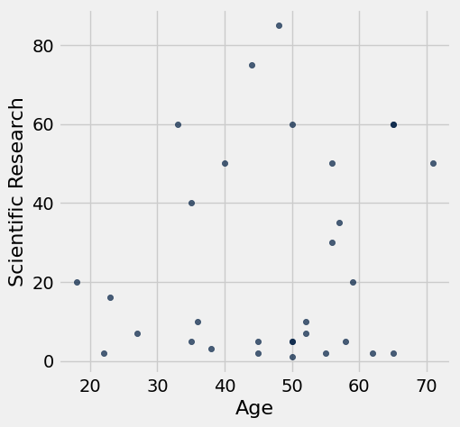

```python
politicDKREF.scatter("Age", "Scientific Research")
```

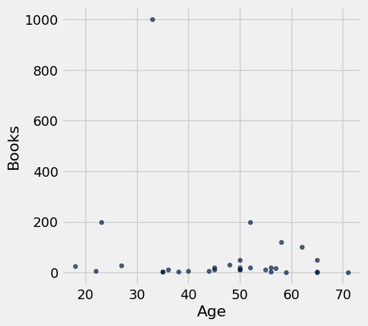

```python
politicDKREF.scatter("Age", "Books")
```

There is no association between Age and Scientific Research or Age and Books for the DK/REF party.

## Conclusion

Both parties are more likely to disagree that automation will replace human employees or that ghosts are real. However, there are more answers for agreeing about the automation event with Independents and Democrats than with other parties. And Democrats and Independents had a lot more answers believing ghosts weren't real then Republicans, showing a trend that Democrats and occasionally, Independents, were more likely to have stronger views on statements than Republicans. For example, on evaluating whether scientists are honest and good, Democrats and Independents were much more likely to choose "Strongly Agree," compared to Republicans who majorly chose more moderate answers. Majority of the Democrats answered that they thought that climate change was real and caused by people, compared to other parties who had more answers for other choices. In contrast, Republicans didn't have a high count for the answer that climate change was real and caused by other people. Democrats also thought that funding for research was too low and majority strongly agreed that vaccines were safe. Republicans on the other hand, mostly answered that the funding is about right and although most strongly agreed about the safety of vaccines, there were more answers disagreeing with this for Republicans than for other parties. Indepedents also strongly agreed that vaccines were safe but had more moderate answers than Democrats. And the age of the people in these political affiliations had no relationship with their logical background, from the books they've read to their guess on the amount of funding on research. An overall pattern between political affiliations of citizens and logical beliefs is that Democrats are more likely to have stronger logical beliefs and positions, especially strongly positive opinions on modern issues like climate change or vaccines. Although all parties agreed with science, Democrats and Independents agreed much more strongly about it. This information can be useful for voters since they can compare their logical beliefs with the trends of the political parties on certain stances and therefore, choose the party to vote for in their next election. This can also be useful for politicians to help their campaigns by finding out the trend for their party on certain logical stances. This can help create an outline to campaign from.

Works Cited: Baker, P. (2022, May 7). Battle over abortion threatens to Deepen America's divide. The New York Times. Retrieved April 4, 2023, from https://www.nytimes.com/2022/05/06/us/politics/abortion-rights-supreme-court-roe-v-wade.html Pasquini, G., & Saks, E. (2022, September 6). Partisan differences are common in the lessons Americans take away from covid-19. Pew Research Center. Retrieved April 4, 2023, from https://www.pewresearch.org/fact-tank/2022/09/06/partisan-differences-are-common-in-the-lessons-americans-take-away-from-covid-19/